# Final Project

Now that you've been guided which experiment to run in assignment 2, you will be exploring on your own, trying to achieve the best accuracy for cifar10.

In this notebook you will be asked to tune some hyperparameters, while it is recommended to tune additional hyperparameters to achieve high performance.

In addition, you will be asked to read some matirials by yourselves, summeraize some of them, and combine thier innovaitive ideas in your network.

You can use part of the data, in order to speed up the training, however, the **dataset size** you test on should be large. Use at least ~12000 training images and ~3000 validation images. The **batch size** parameter however is also up to you (you can increase it in order to speed up the training).

You can run the experiments from several notebooks, while you save the output files in the results dictionary (choose meaningful names) and use 'plot_exp_results' to plot it.

You may want to use loops in order to automatically run each section's experiments.

You will will submit this notebook, all relevant the python files and a report that summerize your attempts and results. Follow the instructions and answer the question in your report.

It is important to describe the hyperparameters you used, how you chose them, and how they affected your results.

**In each section write the best train val and test accuracy and loss.**

```python
!pip install tqdm==4.17.1
import os
import re
import sys
import glob
import numpy as np
import matplotlib.pyplot as plt
import unittest
import torch
import torchvision
import torchvision.transforms as tvtf
import torch.nn as nn
import torch.optim as optim


%matplotlib inline
%load_ext autoreload
%autoreload 2

seed = 42
device = torch.device('cuda' if torch.cuda.is_available() else 'cpu')

plt.rcParams.update({'font.size': 12})
test = unittest.TestCase()
```

```
The autoreload extension is already loaded. To reload it, use:
  %reload_ext autoreload
```

```python
from google.colab import drive
drive.mount('/content/drive')
#change this
%cd /content/drive/MyDrive/deep_learning/assignments/Final
```

```
/content/drive/MyDrive/deep_learning/assignments/Final
```

```python
from utils import *
from  utils import models
import utils.experiments as experiments
from utils.experiments import load_experiment
from utils.plot import plot_fit
import utils.training as training
torch.manual_seed(seed)
```

```
<torch._C.Generator at 0x7d894006b390>
```

```python
!jupyter nbconvert --to html '/content/drive/MyDrive/deep_learning/assignments/Final/Final_Project.ipynb'
```

```
[NbConvertApp] Converting notebook /content/drive/MyDrive/deep_learning/assignments/Final/Final_Project.ipynb to html
[NbConvertApp] Writing 610878 bytes to /content/drive/MyDrive/deep_learning/assignments/Final/Final_Project.html
```

```python
def plot_exp_results(filename_pattern, results_dir='results'):
    fig = None
    result_files = glob.glob(os.path.join(results_dir, filename_pattern))
    result_files.sort()
    if len(result_files) == 0:
        print(f'No results found for pattern {filename_pattern}.', file=sys.stderr)
        return
    for filepath in result_files:
        m = re.match('exp\d_(\d_)?(.*)\.json', os.path.basename(filepath))
        cfg, fit_res = load_experiment(filepath)
        fig, axes = plot_fit(fit_res, fig, legend=m[2], log_loss=True)
        if 'filters_per_layer' in cfg:
            del cfg['filters_per_layer']
        if 'layers_per_block' in cfg:
            del cfg['layers_per_block']
        print('common config: ', cfg)
```

## Build Your Own Achitecture

```python
data_dir = os.path.expanduser('~/.pytorch-datasets')
ds_train = torchvision.datasets.CIFAR10(root=data_dir, download=True, train=True, transform=tvtf.ToTensor())
ds_test = torchvision.datasets.CIFAR10(root=data_dir, download=True, train=False, transform=tvtf.ToTensor())

print(f'Train: {len(ds_train)} samples')
print(f'Test: {len(ds_test)} samples')

x0,_ = ds_train[0]
in_size = x0.shape
num_classes = 10
print('input image size =', in_size)
```

```
Downloading https://www.cs.toronto.edu/~kriz/cifar-10-python.tar.gz to /root/.pytorch-datasets/cifar-10-python.tar.gz
```

```
Extracting /root/.pytorch-datasets/cifar-10-python.tar.gz to /root/.pytorch-datasets
Files already downloaded and verified
Train: 50000 samples
Test: 10000 samples
input image size = torch.Size([3, 32, 32])
```

### 1. Implement YourCodeNet model

Implement YourCodeNet model in utiles/models and define the model architecture (use your previouse assignment's insights). Define `filters_per_layer`, `layers_per_block` and `hidden_dims` which you believe are the best for this task. You can run some experiments in order to set these hyperparameters.

To make the experiment runner use your custom network model, remember to set ycn=True when you call experiments.run_experiment(...).

```python
# Just to see that the model run
net = models.YourCodeNet((3,100,100), 10, filters=[32]*4, pool_every=2, hidden_dims=[100]*2).to(device)
print(net)

test_image = torch.randint(low=0, high=256, size=(3, 100, 100), dtype=torch.float).to(device)
test_out = net(test_image.unsqueeze(0))
print('out =', test_out)
```

```
YourCodeNet(
  (feature_extractor): Sequential(
    (0): Conv2d(3, 32, kernel_size=(3, 3), stride=(1, 1), padding=(1, 1))
    (1): ReLU()
    (2): Conv2d(32, 32, kernel_size=(3, 3), stride=(1, 1), padding=(1, 1))
    (3): ReLU()
    (4): MaxPool2d(kernel_size=2, stride=2, padding=0, dilation=1, ceil_mode=False)
    (5): Conv2d(32, 32, kernel_size=(3, 3), stride=(1, 1), padding=(1, 1))
    (6): ReLU()
    (7): Conv2d(32, 32, kernel_size=(3, 3), stride=(1, 1), padding=(1, 1))
    (8): ReLU()
    (9): MaxPool2d(kernel_size=2, stride=2, padding=0, dilation=1, ceil_mode=False)
  )
  (classifier): Sequential(
    (0): Linear(in_features=20000, out_features=100, bias=True)
    (1): ReLU()
    (2): Linear(in_features=100, out_features=100, bias=True)
    (3): ReLU()
    (4): Linear(in_features=100, out_features=10, bias=True)
  )
)
out = tensor([[-0.0868, -0.3790, -0.4341, -0.1236, -0.2160,  0.1683,  0.4739,  0.0750,
          0.1151, -0.1606]], device='cuda:0', grad_fn=<AddmmBackward0>)
```

```python
experiments.run_experiment(
    run_name=f'exp1_test',
    seed=seed,
    bs_train=128,
    bs_test=None,
    batches=100,
    epochs=100,
    early_stopping=3,
    checkpoints=None,
    lr=1e-3,
    reg=1e-3,
    filters_per_layer=[64, 128, 256],
    layers_per_block=2,
    pool_every=2,
    hidden_dims=[512, 256],
    ycn=True
)

# ========================
```

```
[64, 128, 64, 128]
Files already downloaded and verified
Files already downloaded and verified
--- EPOCH 1/100 ---
train_batch (Avg. Loss 1.795, Accuracy 34.1): 100%|██████████| 100/100 [00:02<00:00, 41.35it/s]
test_batch (Avg. Loss 1.459, Accuracy 45.9): 100%|██████████| 235/235 [00:00<00:00, 439.19it/s]
--- EPOCH 2/100 ---
train_batch (Avg. Loss 1.335, Accuracy 51.6): 100%|██████████| 100/100 [00:01<00:00, 64.02it/s]
test_batch (Avg. Loss 1.204, Accuracy 56.4): 100%|██████████| 235/235 [00:00<00:00, 443.45it/s]
--- EPOCH 3/100 ---
train_batch (Avg. Loss 1.098, Accuracy 60.7): 100%|██████████| 100/100 [00:01<00:00, 64.11it/s]
test_batch (Avg. Loss 1.027, Accuracy 63.0): 100%|██████████| 235/235 [00:00<00:00, 460.01it/s]
--- EPOCH 4/100 ---
train_batch (Avg. Loss 0.925, Accuracy 67.1): 100%|██████████| 100/100 [00:01<00:00, 65.10it/s]
test_batch (Avg. Loss 0.977, Accuracy 65.6): 100%|██████████| 235/235 [00:00<00:00, 458.32it/s]
--- EPOCH 5/100 ---
train_batch (Avg. Loss 0.796, Accuracy 71.7): 100%|██████████| 100/100 [00:01<00:00, 60.40it/s]
test_batch (Avg. Loss 0.845, Accuracy 69.9): 100%|██████████| 235/235 [00:00<00:00, 459.17it/s]
--- EPOCH 6/100 ---
train_batch (Avg. Loss 0.662, Accuracy 76.4): 100%|██████████| 100/100 [00:01<00:00, 65.22it/s]
test_batch (Avg. Loss 0.789, Accuracy 72.0): 100%|██████████| 235/235 [00:00<00:00, 459.69it/s]
--- EPOCH 7/100 ---
train_batch (Avg. Loss 0.542, Accuracy 80.8): 100%|██████████| 100/100 [00:01<00:00, 64.37it/s]
test_batch (Avg. Loss 0.768, Accuracy 73.1): 100%|██████████| 235/235 [00:00<00:00, 453.70it/s]
--- EPOCH 8/100 ---
train_batch (Avg. Loss 0.425, Accuracy 85.1): 100%|██████████| 100/100 [00:01<00:00, 63.05it/s]
test_batch (Avg. Loss 0.830, Accuracy 73.4): 100%|██████████| 235/235 [00:00<00:00, 435.44it/s]
--- EPOCH 9/100 ---
train_batch (Avg. Loss 0.315, Accuracy 89.0): 100%|██████████| 100/100 [00:01<00:00, 63.61it/s]
test_batch (Avg. Loss 0.882, Accuracy 73.9): 100%|██████████| 235/235 [00:00<00:00, 460.56it/s]
--- EPOCH 10/100 ---
train_batch (Avg. Loss 0.199, Accuracy 93.1): 100%|██████████| 100/100 [00:01<00:00, 64.72it/s]
test_batch (Avg. Loss 0.997, Accuracy 73.8): 100%|██████████| 235/235 [00:00<00:00, 456.63it/s]
--- EPOCH 11/100 ---
train_batch (Avg. Loss 0.129, Accuracy 95.5): 100%|██████████| 100/100 [00:01<00:00, 62.55it/s]
test_batch (Avg. Loss 1.118, Accuracy 72.9): 100%|██████████| 235/235 [00:00<00:00, 457.97it/s]
--- EPOCH 12/100 ---
train_batch (Avg. Loss 0.094, Accuracy 96.8): 100%|██████████| 100/100 [00:01<00:00, 62.85it/s]
test_batch (Avg. Loss 1.292, Accuracy 72.8): 100%|██████████| 235/235 [00:00<00:00, 463.60it/s]
*** Early stopping at epoch 12
test_batch (Avg. Loss 1.335, Accuracy 72.5): 100%|██████████| 313/313 [00:02<00:00, 127.33it/s]
==================== Test Results ====================
Test Accuracy: 72.46
Test Loss: 1.3354798640115573
======================================================
*** Output file ./results/exp1_test.json written
```

```
common config:  {'run_name': 'exp1_test', 'out_dir': './results', 'seed': 42, 'optimizer': 'Adam', 'weight_decay': False, 'BatchNorm': False, 'Dropout': False, 'momentum': 0.9, 'bs_train': 128, 'bs_test': 32, 'batches': 100, 'epochs': 100, 'early_stopping': 3, 'checkpoints': None, 'lr': 0.001, 'reg'…
```

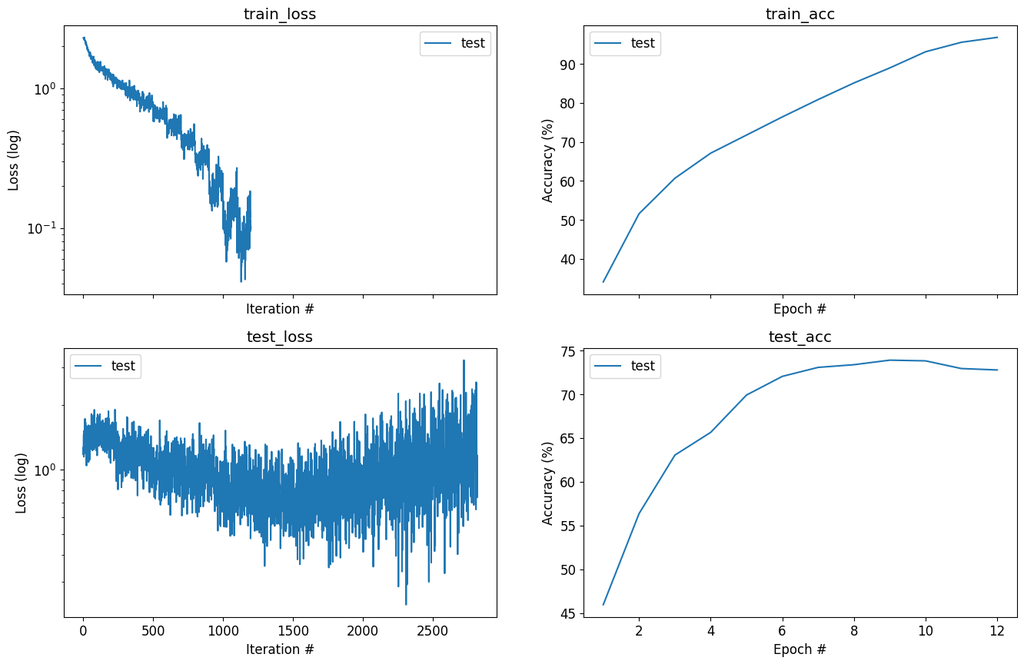

```python
plot_exp_results('exp1_test.json') # plot your experiments results
```

### 2. Learning rate and optimization method

Tune the optimization algorithm (try SGD with momentum and Adam) and the learning rate (try values between 0.0005-1, try no more than five values).

```python
optimizers = ['SGD', 'Adam']
learning_rates = [0.0005, 0.005, 0.05,0.5,1]
for opt in optimizers:
    for lr in learning_rates:
      if opt == 'SGD':
           run_name = f'exp2_opt{opt}_mom_0.9_lr{lr}'  # file name
      else:
           run_name = f'exp2_opt{opt}_lr{lr}'  # file name

      experiments.run_experiment(run_name=run_name,
                                    seed=seed,
                                   optimizer=opt,
                                    bs_train=128,
                                   bs_test=None,
                                   batches=100,
                                    epochs=100,
                                    early_stopping=3,
                                    checkpoints=None,
                                   lr=lr,
                                    reg=1e-3,
                                   filters_per_layer=[64, 128, 256],
                                   layers_per_block=2,
                                    pool_every=2,
                                    hidden_dims=[512, 256],
                                   ycn=True,
                                   momentum=0.9)
```

```
[64, 128, 64, 128]
Files already downloaded and verified
Files already downloaded and verified
--- EPOCH 1/100 ---
train_batch (Avg. Loss 2.303, Accuracy 10.0): 100%|██████████| 100/100 [00:01<00:00, 64.65it/s]
test_batch (Avg. Loss 2.303, Accuracy 10.1): 100%|██████████| 235/235 [00:00<00:00, 409.18it/s]
--- EPOCH 2/100 ---
train_batch (Avg. Loss 2.303, Accuracy 10.0): 100%|██████████| 100/100 [00:01<00:00, 64.36it/s]
test_batch (Avg. Loss 2.303, Accuracy 10.1): 100%|██████████| 235/235 [00:00<00:00, 464.32it/s]
--- EPOCH 3/100 ---
train_batch (Avg. Loss 2.303, Accuracy 10.0): 100%|██████████| 100/100 [00:01<00:00, 65.46it/s]
test_batch (Avg. Loss 2.303, Accuracy 10.1): 100%|██████████| 235/235 [00:00<00:00, 461.21it/s]
--- EPOCH 4/100 ---
train_batch (Avg. Loss 2.303, Accuracy 10.0): 100%|██████████| 100/100 [00:01<00:00, 65.43it/s]
test_batch (Avg. Loss 2.303, Accuracy 10.1): 100%|██████████| 235/235 [00:00<00:00, 466.40it/s]
*** Early stopping at epoch 4
test_batch (Avg. Loss 2.303, Accuracy 10.0): 100%|██████████| 313/313 [00:02<00:00, 127.21it/s]
==================== Test Results ====================
Test Accuracy: 10.0
Test Loss: 2.3026609405541953
======================================================
*** Output file ./results/exp2_optSGD_mom_0.9_lr0.0005.json written
[64, 128, 64, 128]
Files already downloaded and verified
Files already downloaded and verified
--- EPOCH 1/100 ---
train_batch (Avg. Loss 2.303, Accuracy 10.1): 100%|██████████| 100/100 [00:01<00:00, 65.20it/s]
test_batch (Avg. Loss 2.303, Accuracy 10.1): 100%|██████████| 235/235 [00:00<00:00, 473.65it/s]
--- EPOCH 2/100 ---
train_batch (Avg. Loss 2.302, Accuracy 10.4): 100%|██████████| 100/100 [00:01<00:00, 65.93it/s]
test_batch (Avg. Loss 2.302, Accuracy 9.7): 100%|██████████| 235/235 [00:00<00:00, 437.67it/s]
--- EPOCH 3/100 ---
train_batch (Avg. Loss 2.301, Accuracy 10.3): 100%|██████████| 100/100 [00:01<00:00, 65.21it/s]
test_batch (Avg. Loss 2.300, Accuracy 10.1): 100%|██████████| 235/235 [00:00<00:00, 452.70it/s]
--- EPOCH 4/100 ---
train_batch (Avg. Loss 2.297, Accuracy 11.5): 100%|██████████| 100/100 [00:01<00:00, 65.69it/s]
test_batch (Avg. Loss 2.292, Accuracy 13.6): 100%|██████████| 235/235 [00:00<00:00, 449.85it/s]
--- EPOCH 5/100 ---
train_batch (Avg. Loss 2.259, Accuracy 15.7): 100%|██████████| 100/100 [00:01<00:00, 62.72it/s]
test_batch (Avg. Loss 2.153, Accuracy 21.0): 100%|██████████| 235/235 [00:00<00:00, 446.15it/s]
```

[output cut: 390 more lines]

```
train_batch (Avg. Loss 2.312, Accuracy 10.1): 100%|██████████| 100/100 [00:01<00:00, 63.61it/s]
test_batch (Avg. Loss 2.327, Accuracy 9.9): 100%|██████████| 235/235 [00:00<00:00, 449.64it/s]
--- EPOCH 5/100 ---
train_batch (Avg. Loss 2.314, Accuracy 9.7): 100%|██████████| 100/100 [00:01<00:00, 61.80it/s]
test_batch (Avg. Loss 2.307, Accuracy 9.8): 100%|██████████| 235/235 [00:00<00:00, 413.16it/s]
--- EPOCH 6/100 ---
train_batch (Avg. Loss 2.313, Accuracy 10.0): 100%|██████████| 100/100 [00:01<00:00, 64.99it/s]
test_batch (Avg. Loss 2.310, Accuracy 10.1): 100%|██████████| 235/235 [00:00<00:00, 454.01it/s]
*** Early stopping at epoch 6
test_batch (Avg. Loss 2.310, Accuracy 10.0): 100%|██████████| 313/313 [00:02<00:00, 124.60it/s]
==================== Test Results ====================
Test Accuracy: 10.0
Test Loss: 2.309922590804176
======================================================
*** Output file ./results/exp2_optAdam_lr1.json written
```

```
common config:  {'run_name': 'exp2_optAdam_lr0.0005', 'out_dir': './results', 'seed': 42, 'optimizer': 'Adam', 'weight_decay': False, 'BatchNorm': False, 'Dropout': False, 'momentum': 0.9, 'bs_train': 128, 'bs_test': 32, 'batches': 100, 'epochs': 100, 'early_stopping': 3, 'checkpoints': None, 'lr': …
common config:  {'run_name': 'exp2_optAdam_lr0.005', 'out_dir': './results', 'seed': 42, 'optimizer': 'Adam', 'weight_decay': False, 'BatchNorm': False, 'Dropout': False, 'momentum': 0.9, 'bs_train': 128, 'bs_test': 32, 'batches': 100, 'epochs': 100, 'early_stopping': 3, 'checkpoints': None, 'lr': 0…
common config:  {'run_name': 'exp2_optAdam_lr0.05', 'out_dir': './results', 'seed': 42, 'optimizer': 'Adam', 'weight_decay': False, 'BatchNorm': False, 'Dropout': False, 'momentum': 0.9, 'bs_train': 128, 'bs_test': 32, 'batches': 100, 'epochs': 100, 'early_stopping': 3, 'checkpoints': None, 'lr': 0.…
common config:  {'run_name': 'exp2_optAdam_lr0.5', 'out_dir': './results', 'seed': 42, 'optimizer': 'Adam', 'weight_decay': False, 'BatchNorm': False, 'Dropout': False, 'momentum': 0.9, 'bs_train': 128, 'bs_test': 32, 'batches': 100, 'epochs': 100, 'early_stopping': 3, 'checkpoints': None, 'lr': 0.5…
common config:  {'run_name': 'exp2_optAdam_lr1', 'out_dir': './results', 'seed': 42, 'optimizer': 'Adam', 'weight_decay': False, 'BatchNorm': False, 'Dropout': False, 'momentum': 0.9, 'bs_train': 128, 'bs_test': 32, 'batches': 100, 'epochs': 100, 'early_stopping': 3, 'checkpoints': None, 'lr': 1, 'r…
common config:  {'run_name': 'exp2_optSGD_mom_0.9_lr0.0005', 'out_dir': './results', 'seed': 42, 'optimizer': 'SGD', 'weight_decay': False, 'BatchNorm': False, 'Dropout': False, 'momentum': 0.9, 'bs_train': 128, 'bs_test': 32, 'batches': 100, 'epochs': 100, 'early_stopping': 3, 'checkpoints': None, …
common config:  {'run_name': 'exp2_optSGD_mom_0.9_lr0.005', 'out_dir': './results', 'seed': 42, 'optimizer': 'SGD', 'weight_decay': False, 'BatchNorm': False, 'Dropout': False, 'momentum': 0.9, 'bs_train': 128, 'bs_test': 32, 'batches': 100, 'epochs': 100, 'early_stopping': 3, 'checkpoints': None, '…
common config:  {'run_name': 'exp2_optSGD_mom_0.9_lr0.05', 'out_dir': './results', 'seed': 42, 'optimizer': 'SGD', 'weight_decay': False, 'BatchNorm': False, 'Dropout': False, 'momentum': 0.9, 'bs_train': 128, 'bs_test': 32, 'batches': 100, 'epochs': 100, 'early_stopping': 3, 'checkpoints': None, 'l…
common config:  {'run_name': 'exp2_optSGD_mom_0.9_lr0.5', 'out_dir': './results', 'seed': 42, 'optimizer': 'SGD', 'weight_decay': False, 'BatchNorm': False, 'Dropout': False, 'momentum': 0.9, 'bs_train': 128, 'bs_test': 32, 'batches': 100, 'epochs': 100, 'early_stopping': 3, 'checkpoints': None, 'lr…
common config:  {'run_name': 'exp2_optSGD_mom_0.9_lr1', 'out_dir': './results', 'seed': 42, 'optimizer': 'SGD', 'weight_decay': False, 'BatchNorm': False, 'Dropout': False, 'momentum': 0.9, 'bs_train': 128, 'bs_test': 32, 'batches': 100, 'epochs': 100, 'early_stopping': 3, 'checkpoints': None, 'lr':…
```

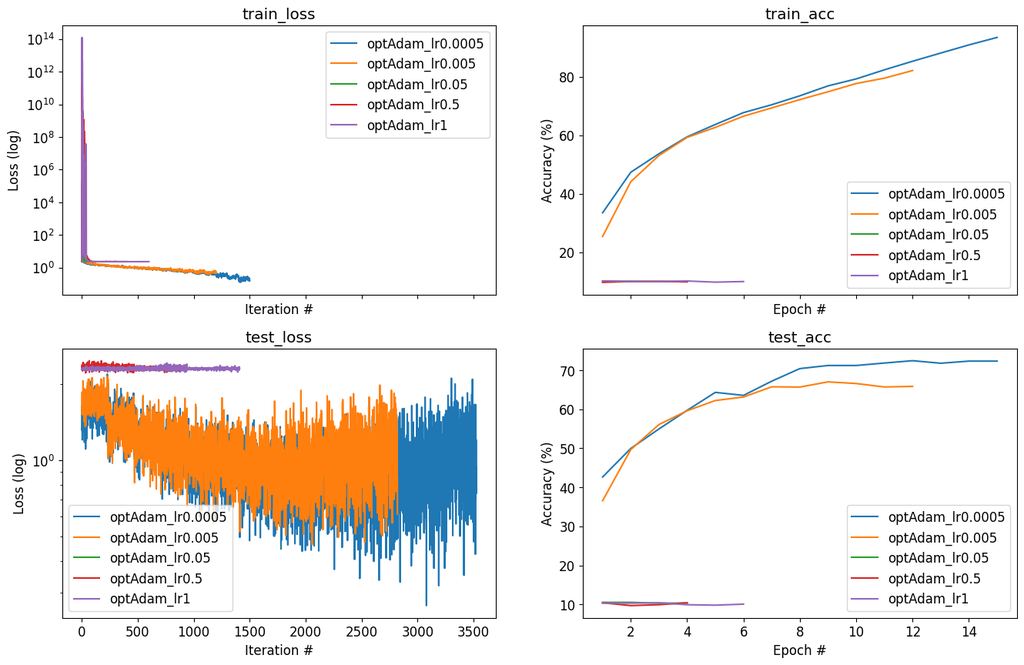

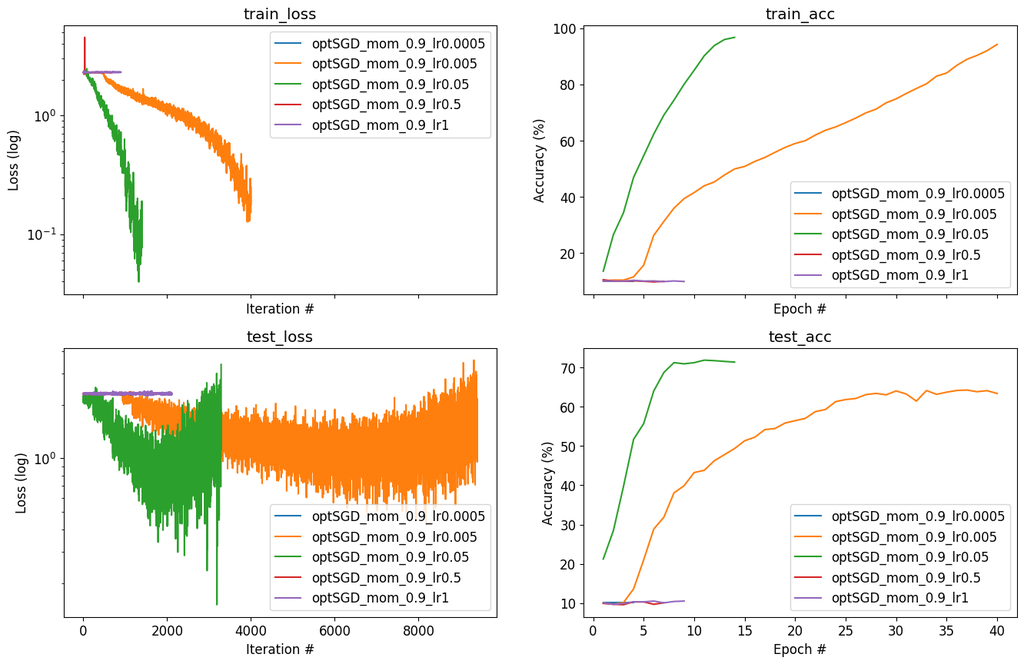

```python
# For Adam
plot_exp_results('exp2_*Adam*.json')

# For SGD
plot_exp_results('exp2_*SGD*.json')
```

**Answer in your Report:** Why should we add the momentum to SGD? What is the main two improvments adam has comparing to the simple SGD? What was the best optimization algorithm and best learning rate you've found?

Summarize this section results in your report.

**Note** - you will need to change the optimization used in experiments.run_experiment(...).

### 3. Add Batch Normalization

Add batch normalization to your network. You may want to read this blog before: https://www.baeldung.com/cs/batch-normalization-cnn

```python
optimizers = ['SGD', 'Adam']
learning_rates = [0.0005, 0.005, 0.05,0.5,1]
for opt in optimizers:
    for lr in learning_rates:
      if opt == 'SGD':
           run_name = f'exp3_opt{opt}_mom_0.9_lr{lr}'  # file name
      else:
           run_name = f'exp3_opt{opt}_lr{lr}'  # file name

      experiments.run_experiment(run_name=run_name,
                                    seed=seed,
                                   optimizer=opt,
                                    bs_train=128,
                                   bs_test=None,
                                   batches=100,
                                    epochs=100,
                                    early_stopping=3,
                                    checkpoints=None,
                                   lr=lr,
                                    reg=1e-3,
                                   filters_per_layer=[64, 128, 256],
                                   layers_per_block=2,
                                    pool_every=2,
                                    hidden_dims=[512, 256],
                                   ycn=True,
                                   momentum=0.9,
                                 BatchNorm=True)
```

```
[64, 128, 64, 128]
Files already downloaded and verified
Files already downloaded and verified
--- EPOCH 1/100 ---
train_batch (Avg. Loss 2.180, Accuracy 23.6): 100%|██████████| 100/100 [00:02<00:00, 44.04it/s]
test_batch (Avg. Loss 1.991, Accuracy 34.5): 100%|██████████| 235/235 [00:00<00:00, 414.35it/s]
--- EPOCH 2/100 ---
train_batch (Avg. Loss 1.830, Accuracy 38.4): 100%|██████████| 100/100 [00:01<00:00, 50.18it/s]
test_batch (Avg. Loss 1.696, Accuracy 40.3): 100%|██████████| 235/235 [00:00<00:00, 398.45it/s]
--- EPOCH 3/100 ---
train_batch (Avg. Loss 1.610, Accuracy 43.5): 100%|██████████| 100/100 [00:02<00:00, 49.20it/s]
test_batch (Avg. Loss 1.531, Accuracy 45.4): 100%|██████████| 235/235 [00:00<00:00, 417.61it/s]
--- EPOCH 4/100 ---
train_batch (Avg. Loss 1.464, Accuracy 48.3): 100%|██████████| 100/100 [00:02<00:00, 48.69it/s]
test_batch (Avg. Loss 1.407, Accuracy 49.1): 100%|██████████| 235/235 [00:00<00:00, 422.44it/s]
--- EPOCH 5/100 ---
train_batch (Avg. Loss 1.358, Accuracy 52.0): 100%|██████████| 100/100 [00:02<00:00, 49.49it/s]
test_batch (Avg. Loss 1.328, Accuracy 52.0): 100%|██████████| 235/235 [00:00<00:00, 420.91it/s]
--- EPOCH 6/100 ---
train_batch (Avg. Loss 1.273, Accuracy 54.9): 100%|██████████| 100/100 [00:02<00:00, 48.67it/s]
test_batch (Avg. Loss 1.252, Accuracy 54.3): 100%|██████████| 235/235 [00:00<00:00, 424.76it/s]
--- EPOCH 7/100 ---
train_batch (Avg. Loss 1.200, Accuracy 57.8): 100%|██████████| 100/100 [00:02<00:00, 48.27it/s]
test_batch (Avg. Loss 1.185, Accuracy 57.0): 100%|██████████| 235/235 [00:00<00:00, 406.25it/s]
--- EPOCH 8/100 ---
train_batch (Avg. Loss 1.138, Accuracy 59.9): 100%|██████████| 100/100 [00:02<00:00, 47.32it/s]
test_batch (Avg. Loss 1.134, Accuracy 59.0): 100%|██████████| 235/235 [00:00<00:00, 416.49it/s]
--- EPOCH 9/100 ---
train_batch (Avg. Loss 1.081, Accuracy 62.0): 100%|██████████| 100/100 [00:02<00:00, 48.05it/s]
test_batch (Avg. Loss 1.085, Accuracy 61.2): 100%|██████████| 235/235 [00:00<00:00, 416.44it/s]
--- EPOCH 10/100 ---
train_batch (Avg. Loss 1.025, Accuracy 64.0): 100%|██████████| 100/100 [00:02<00:00, 48.34it/s]
test_batch (Avg. Loss 1.043, Accuracy 62.8): 100%|██████████| 235/235 [00:00<00:00, 420.06it/s]
--- EPOCH 11/100 ---
train_batch (Avg. Loss 0.976, Accuracy 65.9): 100%|██████████| 100/100 [00:02<00:00, 47.42it/s]
test_batch (Avg. Loss 1.024, Accuracy 64.2): 100%|██████████| 235/235 [00:00<00:00, 400.08it/s]
--- EPOCH 12/100 ---
train_batch (Avg. Loss 0.935, Accuracy 67.4): 100%|██████████| 100/100 [00:02<00:00, 48.55it/s]
test_batch (Avg. Loss 0.969, Accuracy 65.7): 100%|██████████| 235/235 [00:00<00:00, 420.95it/s]
--- EPOCH 13/100 ---
```

[output cut: 411 more lines]

```
train_batch (Avg. Loss 2.382, Accuracy 9.6): 100%|██████████| 100/100 [00:01<00:00, 51.29it/s]
test_batch (Avg. Loss 4.734, Accuracy 10.3): 100%|██████████| 235/235 [00:00<00:00, 413.83it/s]
--- EPOCH 4/100 ---
train_batch (Avg. Loss 2.315, Accuracy 10.3): 100%|██████████| 100/100 [00:01<00:00, 51.20it/s]
test_batch (Avg. Loss 5.752, Accuracy 9.9): 100%|██████████| 235/235 [00:00<00:00, 408.57it/s]
--- EPOCH 5/100 ---
train_batch (Avg. Loss 2.320, Accuracy 9.9): 100%|██████████| 100/100 [00:01<00:00, 51.23it/s]
test_batch (Avg. Loss 5.672, Accuracy 9.8): 100%|██████████| 235/235 [00:00<00:00, 407.73it/s]
*** Early stopping at epoch 5
test_batch (Avg. Loss 2.314, Accuracy 10.0): 100%|██████████| 313/313 [00:02<00:00, 116.45it/s]
==================== Test Results ====================
Test Accuracy: 10.0
Test Loss: 2.3136720314574317
======================================================
*** Output file ./results/exp3_optAdam_lr1.json written
```

```
common config:  {'run_name': 'exp3_optAdam_lr0.0005', 'out_dir': './results', 'seed': 42, 'optimizer': 'Adam', 'weight_decay': False, 'BatchNorm': True, 'Dropout': False, 'momentum': 0.9, 'bs_train': 128, 'bs_test': 32, 'batches': 100, 'epochs': 100, 'early_stopping': 3, 'checkpoints': None, 'lr': 0…
common config:  {'run_name': 'exp3_optAdam_lr0.005', 'out_dir': './results', 'seed': 42, 'optimizer': 'Adam', 'weight_decay': False, 'BatchNorm': True, 'Dropout': False, 'momentum': 0.9, 'bs_train': 128, 'bs_test': 32, 'batches': 100, 'epochs': 100, 'early_stopping': 3, 'checkpoints': None, 'lr': 0.…
common config:  {'run_name': 'exp3_optAdam_lr0.05', 'out_dir': './results', 'seed': 42, 'optimizer': 'Adam', 'weight_decay': False, 'BatchNorm': True, 'Dropout': False, 'momentum': 0.9, 'bs_train': 128, 'bs_test': 32, 'batches': 100, 'epochs': 100, 'early_stopping': 3, 'checkpoints': None, 'lr': 0.0…
common config:  {'run_name': 'exp3_optAdam_lr0.5', 'out_dir': './results', 'seed': 42, 'optimizer': 'Adam', 'weight_decay': False, 'BatchNorm': True, 'Dropout': False, 'momentum': 0.9, 'bs_train': 128, 'bs_test': 32, 'batches': 100, 'epochs': 100, 'early_stopping': 3, 'checkpoints': None, 'lr': 0.5,…
common config:  {'run_name': 'exp3_optAdam_lr1', 'out_dir': './results', 'seed': 42, 'optimizer': 'Adam', 'weight_decay': False, 'BatchNorm': True, 'Dropout': False, 'momentum': 0.9, 'bs_train': 128, 'bs_test': 32, 'batches': 100, 'epochs': 100, 'early_stopping': 3, 'checkpoints': None, 'lr': 1, 're…
common config:  {'run_name': 'exp3_optSGD_mom_0.9_lr0.0005', 'out_dir': './results', 'seed': 42, 'optimizer': 'SGD', 'weight_decay': False, 'BatchNorm': True, 'Dropout': False, 'momentum': 0.9, 'bs_train': 128, 'bs_test': 32, 'batches': 100, 'epochs': 100, 'early_stopping': 3, 'checkpoints': None, '…
common config:  {'run_name': 'exp3_optSGD_mom_0.9_lr0.005', 'out_dir': './results', 'seed': 42, 'optimizer': 'SGD', 'weight_decay': False, 'BatchNorm': True, 'Dropout': False, 'momentum': 0.9, 'bs_train': 128, 'bs_test': 32, 'batches': 100, 'epochs': 100, 'early_stopping': 3, 'checkpoints': None, 'l…
common config:  {'run_name': 'exp3_optSGD_mom_0.9_lr0.05', 'out_dir': './results', 'seed': 42, 'optimizer': 'SGD', 'weight_decay': False, 'BatchNorm': True, 'Dropout': False, 'momentum': 0.9, 'bs_train': 128, 'bs_test': 32, 'batches': 100, 'epochs': 100, 'early_stopping': 3, 'checkpoints': None, 'lr…
common config:  {'run_name': 'exp3_optSGD_mom_0.9_lr0.5', 'out_dir': './results', 'seed': 42, 'optimizer': 'SGD', 'weight_decay': False, 'BatchNorm': True, 'Dropout': False, 'momentum': 0.9, 'bs_train': 128, 'bs_test': 32, 'batches': 100, 'epochs': 100, 'early_stopping': 3, 'checkpoints': None, 'lr'…
common config:  {'run_name': 'exp3_optSGD_mom_0.9_lr1', 'out_dir': './results', 'seed': 42, 'optimizer': 'SGD', 'weight_decay': False, 'BatchNorm': True, 'Dropout': False, 'momentum': 0.9, 'bs_train': 128, 'bs_test': 32, 'batches': 100, 'epochs': 100, 'early_stopping': 3, 'checkpoints': None, 'lr': …
```

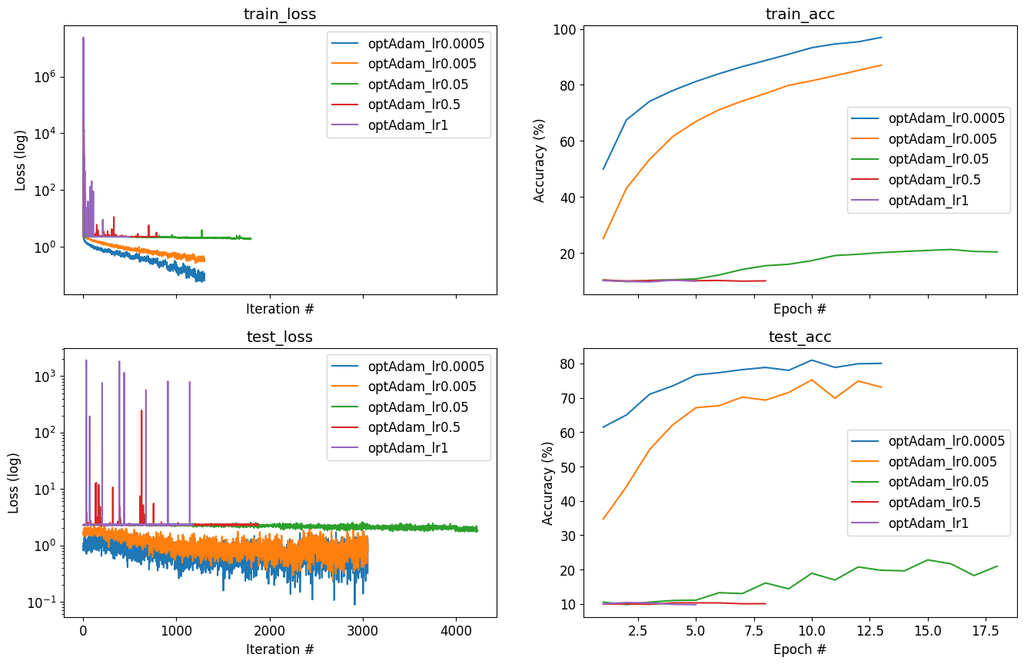

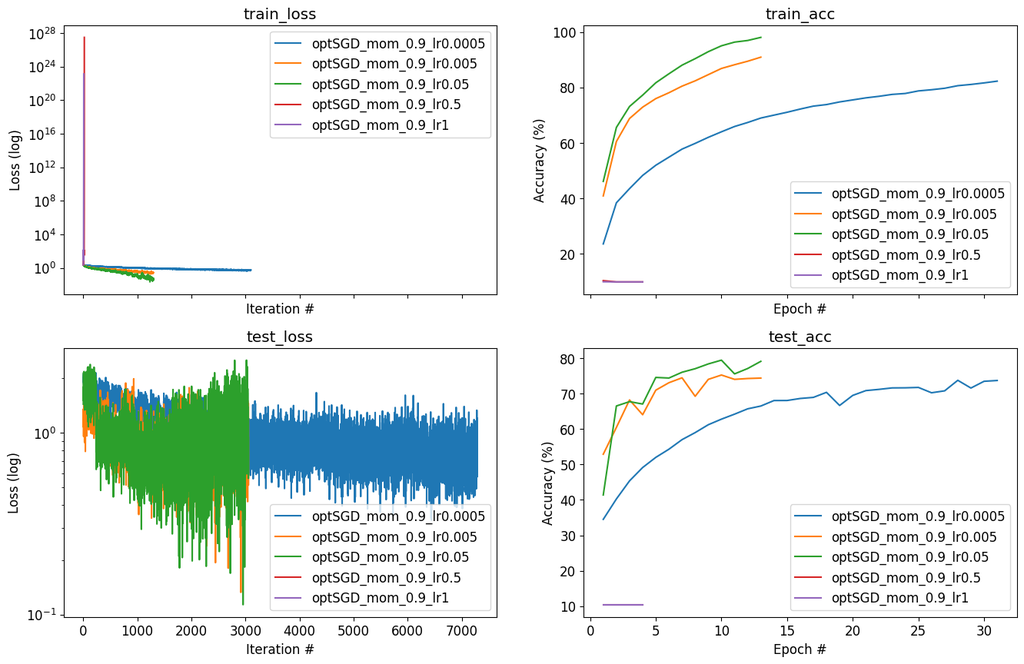

```python
# For Adam
plot_exp_results('exp3_*Adam*.json')

# For SGD
plot_exp_results('exp3_*SGD*.json')
```

**Answer in your Report:** What is the purpose of batch normalization (why do we use it)? Did the Batch normalization improve the network preformance? Summeraize this section results in your report.

### 4. Regularization

Try to add regularization to your optimization. In particular add L2 regularization (read about weight_decay in adam) and dropout layer to your network (try them separately).

```python
learning_rates = [0.0005, 0.005]
regularization=[1e-5,1e-4,1e-3]
optimizers = ['SGD', 'Adam']


# regularization
for opt in optimizers:
    for lr in learning_rates:
        for reg in regularization:
            if opt == 'SGD':
                run_name = f'exp4_opt{opt}_mom_0.9_lr{lr}_BatchNorm_weight_decay{reg}'  # file name
            else:
                run_name = f'exp4_opt{opt}_lr{lr}_BatchNorm_weight_decay{reg}'  # file name

            experiments.run_experiment(
                run_name=run_name,
                seed=seed,
                optimizer=opt,
                bs_train=128,
                bs_test=None,
                batches=100,
                epochs=100,
                early_stopping=3,
                checkpoints=None,
                lr=lr,
                reg=reg,
                filters_per_layer=[64, 128, 256],
                layers_per_block=2,
                pool_every=2,
                hidden_dims=[512, 256],
                ycn=True,
                momentum=0.9 if opt == 'SGD' else None,
            )




# Dropout
for opt in optimizers:
    for lr in learning_rates:
      if opt == 'SGD':
           run_name = f'exp5_opt{opt}_mom_0.9_lr{lr}_Dropout'  # file name
      else:
           run_name = f'exp5_opt{opt}_lr{lr}_Dropout'  # file name

      experiments.run_experiment(run_name=run_name,
                                    seed=seed,
                                   optimizer=opt,
                                    bs_train=128,
                                   bs_test=None,
                                   batches=100,
                                    epochs=100,
                                    early_stopping=3,
                                    checkpoints=None,
                                   lr=lr,
                                    reg=1e-3,
                                   filters_per_layer=[64, 128, 256],
                                   layers_per_block=2,
                                    pool_every=2,
                                    hidden_dims=[512, 256],
                                   ycn=True,
                                   momentum=0.9,
                                 BatchNorm=True,
                                 Dropout=True)

# ========================
```

```
[64, 128, 64, 128]
Files already downloaded and verified
Files already downloaded and verified
--- EPOCH 1/100 ---
train_batch (Avg. Loss 2.303, Accuracy 10.0): 100%|██████████| 100/100 [00:01<00:00, 62.97it/s]
test_batch (Avg. Loss 2.303, Accuracy 10.1): 100%|██████████| 235/235 [00:00<00:00, 460.50it/s]
--- EPOCH 2/100 ---
train_batch (Avg. Loss 2.303, Accuracy 10.0): 100%|██████████| 100/100 [00:01<00:00, 63.86it/s]
test_batch (Avg. Loss 2.303, Accuracy 10.1): 100%|██████████| 235/235 [00:00<00:00, 459.98it/s]
--- EPOCH 3/100 ---
train_batch (Avg. Loss 2.303, Accuracy 10.0): 100%|██████████| 100/100 [00:01<00:00, 62.27it/s]
test_batch (Avg. Loss 2.303, Accuracy 10.1): 100%|██████████| 235/235 [00:00<00:00, 441.51it/s]
--- EPOCH 4/100 ---
train_batch (Avg. Loss 2.303, Accuracy 10.0): 100%|██████████| 100/100 [00:01<00:00, 62.24it/s]
test_batch (Avg. Loss 2.303, Accuracy 10.1): 100%|██████████| 235/235 [00:00<00:00, 425.02it/s]
*** Early stopping at epoch 4
test_batch (Avg. Loss 2.303, Accuracy 10.0): 100%|██████████| 313/313 [00:02<00:00, 122.68it/s]
==================== Test Results ====================
Test Accuracy: 10.0
Test Loss: 2.302660944362799
======================================================
*** Output file ./results/exp4_optSGD_mom_0.9_lr0.0005_BatchNorm_weight_decay1e-05.json written
[64, 128, 64, 128]
Files already downloaded and verified
Files already downloaded and verified
--- EPOCH 1/100 ---
train_batch (Avg. Loss 2.303, Accuracy 10.0): 100%|██████████| 100/100 [00:01<00:00, 63.78it/s]
test_batch (Avg. Loss 2.303, Accuracy 10.1): 100%|██████████| 235/235 [00:00<00:00, 454.19it/s]
--- EPOCH 2/100 ---
train_batch (Avg. Loss 2.303, Accuracy 10.0): 100%|██████████| 100/100 [00:01<00:00, 64.29it/s]
test_batch (Avg. Loss 2.303, Accuracy 10.1): 100%|██████████| 235/235 [00:00<00:00, 464.54it/s]
--- EPOCH 3/100 ---
train_batch (Avg. Loss 2.303, Accuracy 10.0): 100%|██████████| 100/100 [00:01<00:00, 62.35it/s]
test_batch (Avg. Loss 2.303, Accuracy 10.1): 100%|██████████| 235/235 [00:00<00:00, 357.42it/s]
--- EPOCH 4/100 ---
train_batch (Avg. Loss 2.303, Accuracy 10.0): 100%|██████████| 100/100 [00:01<00:00, 62.27it/s]
test_batch (Avg. Loss 2.303, Accuracy 10.1): 100%|██████████| 235/235 [00:00<00:00, 453.11it/s]
*** Early stopping at epoch 4
test_batch (Avg. Loss 2.303, Accuracy 10.0): 100%|██████████| 313/313 [00:02<00:00, 125.24it/s]
==================== Test Results ====================
```

[output cut: 1029 more lines]

```
train_batch (Avg. Loss 0.378, Accuracy 86.8): 100%|██████████| 100/100 [00:01<00:00, 50.49it/s]
test_batch (Avg. Loss 0.712, Accuracy 78.2): 100%|██████████| 235/235 [00:00<00:00, 380.46it/s]
--- EPOCH 29/100 ---
train_batch (Avg. Loss 0.373, Accuracy 86.9): 100%|██████████| 100/100 [00:01<00:00, 50.88it/s]
test_batch (Avg. Loss 0.636, Accuracy 78.9): 100%|██████████| 235/235 [00:00<00:00, 399.03it/s]
--- EPOCH 30/100 ---
train_batch (Avg. Loss 0.362, Accuracy 87.3): 100%|██████████| 100/100 [00:01<00:00, 50.58it/s]
test_batch (Avg. Loss 0.701, Accuracy 78.6): 100%|██████████| 235/235 [00:00<00:00, 375.82it/s]
*** Early stopping at epoch 30
test_batch (Avg. Loss 0.718, Accuracy 77.8): 100%|██████████| 313/313 [00:02<00:00, 114.71it/s]
==================== Test Results ====================
Test Accuracy: 77.81
Test Loss: 0.7177197820367143
======================================================
*** Output file ./results/exp5_optAdam_lr0.005_Dropout.json written
```

```
common config:  {'run_name': 'exp4_optAdam_lr0.0005_BatchNorm_weight_decay0.0001', 'out_dir': './results', 'seed': 42, 'optimizer': 'Adam', 'weight_decay': False, 'BatchNorm': False, 'Dropout': False, 'momentum': None, 'bs_train': 128, 'bs_test': 32, 'batches': 100, 'epochs': 100, 'early_stopping': …
common config:  {'run_name': 'exp4_optAdam_lr0.0005_BatchNorm_weight_decay0.001', 'out_dir': './results', 'seed': 42, 'optimizer': 'Adam', 'weight_decay': False, 'BatchNorm': False, 'Dropout': False, 'momentum': None, 'bs_train': 128, 'bs_test': 32, 'batches': 100, 'epochs': 100, 'early_stopping': 3…
common config:  {'run_name': 'exp4_optAdam_lr0.0005_BatchNorm_weight_decay1e-05', 'out_dir': './results', 'seed': 42, 'optimizer': 'Adam', 'weight_decay': False, 'BatchNorm': False, 'Dropout': False, 'momentum': None, 'bs_train': 128, 'bs_test': 32, 'batches': 100, 'epochs': 100, 'early_stopping': 3…
common config:  {'run_name': 'exp4_optAdam_lr0.005_BatchNorm_weight_decay0.0001', 'out_dir': './results', 'seed': 42, 'optimizer': 'Adam', 'weight_decay': False, 'BatchNorm': False, 'Dropout': False, 'momentum': None, 'bs_train': 128, 'bs_test': 32, 'batches': 100, 'epochs': 100, 'early_stopping': 3…
common config:  {'run_name': 'exp4_optAdam_lr0.005_BatchNorm_weight_decay0.001', 'out_dir': './results', 'seed': 42, 'optimizer': 'Adam', 'weight_decay': False, 'BatchNorm': False, 'Dropout': False, 'momentum': None, 'bs_train': 128, 'bs_test': 32, 'batches': 100, 'epochs': 100, 'early_stopping': 3,…
common config:  {'run_name': 'exp4_optAdam_lr0.005_BatchNorm_weight_decay1e-05', 'out_dir': './results', 'seed': 42, 'optimizer': 'Adam', 'weight_decay': False, 'BatchNorm': False, 'Dropout': False, 'momentum': None, 'bs_train': 128, 'bs_test': 32, 'batches': 100, 'epochs': 100, 'early_stopping': 3,…
common config:  {'run_name': 'exp4_optSGD_mom_0.9_lr0.0005_BatchNorm_weight_decay0.0001', 'out_dir': './results', 'seed': 42, 'optimizer': 'SGD', 'weight_decay': False, 'BatchNorm': False, 'Dropout': False, 'momentum': 0.9, 'bs_train': 128, 'bs_test': 32, 'batches': 100, 'epochs': 100, 'early_stoppi…
common config:  {'run_name': 'exp4_optSGD_mom_0.9_lr0.0005_BatchNorm_weight_decay0.001', 'out_dir': './results', 'seed': 42, 'optimizer': 'SGD', 'weight_decay': False, 'BatchNorm': False, 'Dropout': False, 'momentum': 0.9, 'bs_train': 128, 'bs_test': 32, 'batches': 100, 'epochs': 100, 'early_stoppin…
common config:  {'run_name': 'exp4_optSGD_mom_0.9_lr0.0005_BatchNorm_weight_decay1e-05', 'out_dir': './results', 'seed': 42, 'optimizer': 'SGD', 'weight_decay': False, 'BatchNorm': False, 'Dropout': False, 'momentum': 0.9, 'bs_train': 128, 'bs_test': 32, 'batches': 100, 'epochs': 100, 'early_stoppin…
common config:  {'run_name': 'exp4_optSGD_mom_0.9_lr0.005_BatchNorm_weight_decay0.0001', 'out_dir': './results', 'seed': 42, 'optimizer': 'SGD', 'weight_decay': False, 'BatchNorm': False, 'Dropout': False, 'momentum': 0.9, 'bs_train': 128, 'bs_test': 32, 'batches': 100, 'epochs': 100, 'early_stoppin…
common config:  {'run_name': 'exp4_optSGD_mom_0.9_lr0.005_BatchNorm_weight_decay0.001', 'out_dir': './results', 'seed': 42, 'optimizer': 'SGD', 'weight_decay': False, 'BatchNorm': False, 'Dropout': False, 'momentum': 0.9, 'bs_train': 128, 'bs_test': 32, 'batches': 100, 'epochs': 100, 'early_stopping…
common config:  {'run_name': 'exp4_optSGD_mom_0.9_lr0.005_BatchNorm_weight_decay1e-05', 'out_dir': './results', 'seed': 42, 'optimizer': 'SGD', 'weight_decay': False, 'BatchNorm': False, 'Dropout': False, 'momentum': 0.9, 'bs_train': 128, 'bs_test': 32, 'batches': 100, 'epochs': 100, 'early_stopping…
```

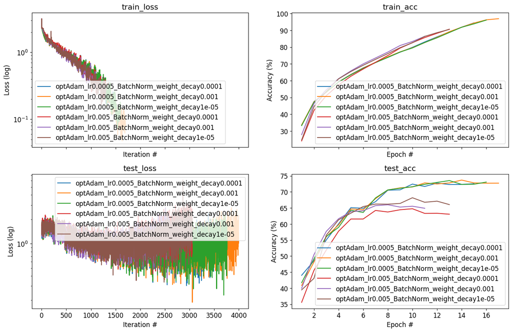

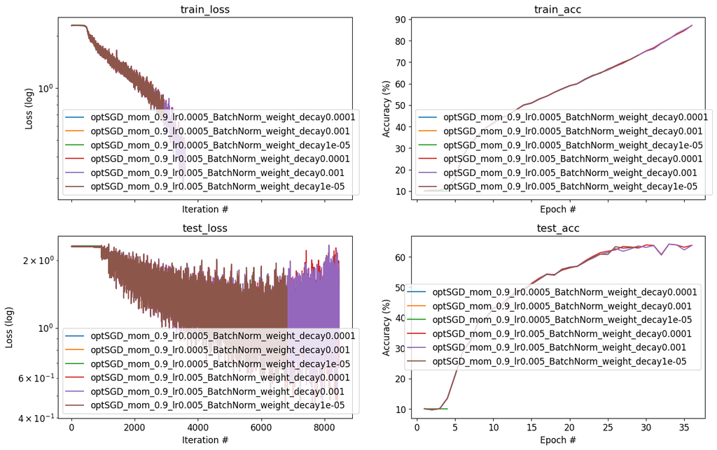

```python
# For Adam
plot_exp_results('exp4_*Adam*.json')

# For SGD
plot_exp_results('exp4_*SGD*.json')
```

```
common config:  {'run_name': 'exp5_optAdam_lr0.0005_Dropout', 'out_dir': './results', 'seed': 42, 'optimizer': 'Adam', 'weight_decay': False, 'BatchNorm': True, 'Dropout': True, 'momentum': 0.9, 'bs_train': 128, 'bs_test': 32, 'batches': 100, 'epochs': 100, 'early_stopping': 3, 'checkpoints': None, …
common config:  {'run_name': 'exp5_optAdam_lr0.005_Dropout', 'out_dir': './results', 'seed': 42, 'optimizer': 'Adam', 'weight_decay': False, 'BatchNorm': True, 'Dropout': True, 'momentum': 0.9, 'bs_train': 128, 'bs_test': 32, 'batches': 100, 'epochs': 100, 'early_stopping': 3, 'checkpoints': None, '…
common config:  {'run_name': 'exp5_optAdam_lr0.05_Dropout', 'out_dir': './results', 'seed': 42, 'optimizer': 'Adam', 'weight_decay': False, 'BatchNorm': True, 'Dropout': True, 'momentum': 0.9, 'bs_train': 128, 'bs_test': 32, 'batches': 100, 'epochs': 100, 'early_stopping': 3, 'checkpoints': None, 'l…
common config:  {'run_name': 'exp5_optAdam_lr0.5_Dropout', 'out_dir': './results', 'seed': 42, 'optimizer': 'Adam', 'weight_decay': False, 'BatchNorm': True, 'Dropout': True, 'momentum': 0.9, 'bs_train': 128, 'bs_test': 32, 'batches': 100, 'epochs': 100, 'early_stopping': 3, 'checkpoints': None, 'lr…
common config:  {'run_name': 'exp5_optAdam_lr1_Dropout', 'out_dir': './results', 'seed': 42, 'optimizer': 'Adam', 'weight_decay': False, 'BatchNorm': True, 'Dropout': True, 'momentum': 0.9, 'bs_train': 128, 'bs_test': 32, 'batches': 100, 'epochs': 100, 'early_stopping': 3, 'checkpoints': None, 'lr':…
common config:  {'run_name': 'exp5_optSGD_mom_0.9_lr0.0005_Dropout', 'out_dir': './results', 'seed': 42, 'optimizer': 'SGD', 'weight_decay': False, 'BatchNorm': True, 'Dropout': True, 'momentum': 0.9, 'bs_train': 128, 'bs_test': 32, 'batches': 100, 'epochs': 100, 'early_stopping': 3, 'checkpoints': …
common config:  {'run_name': 'exp5_optSGD_mom_0.9_lr0.005_Dropout', 'out_dir': './results', 'seed': 42, 'optimizer': 'SGD', 'weight_decay': False, 'BatchNorm': True, 'Dropout': True, 'momentum': 0.9, 'bs_train': 128, 'bs_test': 32, 'batches': 100, 'epochs': 100, 'early_stopping': 3, 'checkpoints': N…
common config:  {'run_name': 'exp5_optSGD_mom_0.9_lr0.05_Dropout', 'out_dir': './results', 'seed': 42, 'optimizer': 'SGD', 'weight_decay': False, 'BatchNorm': True, 'Dropout': True, 'momentum': 0.9, 'bs_train': 128, 'bs_test': 32, 'batches': 100, 'epochs': 100, 'early_stopping': 3, 'checkpoints': No…
common config:  {'run_name': 'exp5_optSGD_mom_0.9_lr0.5_Dropout', 'out_dir': './results', 'seed': 42, 'optimizer': 'SGD', 'weight_decay': False, 'BatchNorm': True, 'Dropout': True, 'momentum': 0.9, 'bs_train': 128, 'bs_test': 32, 'batches': 100, 'epochs': 100, 'early_stopping': 3, 'checkpoints': Non…
common config:  {'run_name': 'exp5_optSGD_mom_0.9_lr1_Dropout', 'out_dir': './results', 'seed': 42, 'optimizer': 'SGD', 'weight_decay': False, 'BatchNorm': True, 'Dropout': True, 'momentum': 0.9, 'bs_train': 128, 'bs_test': 32, 'batches': 100, 'epochs': 100, 'early_stopping': 3, 'checkpoints': None,…
```

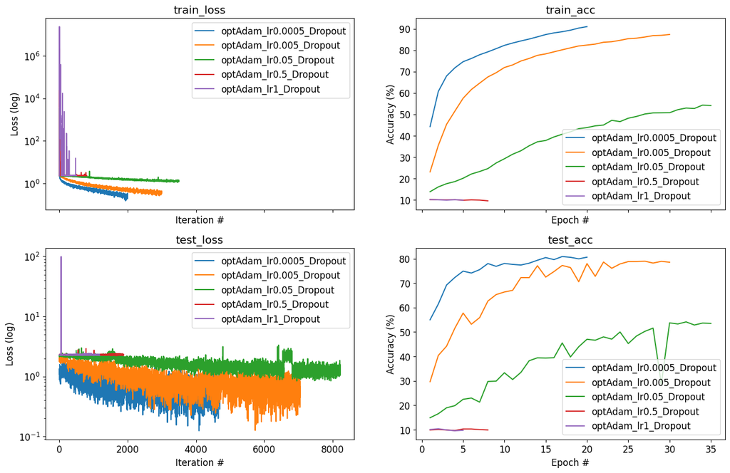

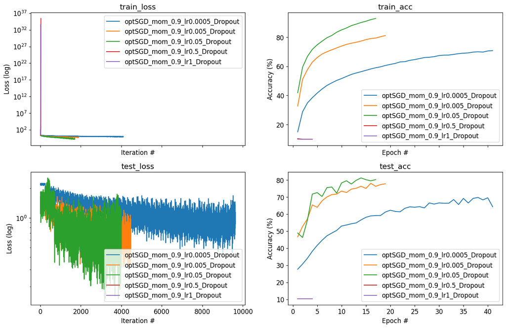

```python
# For Adam
plot_exp_results('exp5_*Adam*.json')

# For SGD
plot_exp_results('exp5_*SGD*.json')
```

**Answer in your Report:** Why should we use regularization? How does the regularization affect the train accuracy and loss? How does it affect the val and test accuracy and loss? What was the best regulrization method? Summarize this section results in your report.

## Summary Up To Here

**Answer in your Report:** What is your best architecture? what its best accuracy and loss on the test set? Compare your result to assignment 2. How did you mange to improve the model? Summarize this section results in your report.

## Use predefined network

You may want to read about ResNet in this blog:

https://towardsdatascience.com/an-overview-of-resnet-and-its-variants-5281e2f56035

### 5. Pretrained ResNet50

Now use ResNet50 with pretraining (use pretrained=True when you load the model) and run this model on cifar 10. you will need to change the last linear layer. Tip: `model.fc = nn.Linear(2048, 10)`. you may want to use lower learning rate.

```python
import torchvision.models as models
import torch.optim as optim

# Define the batch size
batch_size = 32  # you can change this value depending on your GPU capacity

# Create data loaders
train_loader = torch.utils.data.DataLoader(ds_train, batch_size=batch_size, shuffle=True)
val_loader = torch.utils.data.DataLoader(ds_test, batch_size=batch_size, shuffle=False)
dl_test = torch.utils.data.DataLoader(ds_test,batch_size=batch_size, shuffle=False)



# Load the model
model = models.resnet50(pretrained=True)
model.fc = nn.Linear(2048, 10)  # adjust the last layer

# Set the loss function and the optimizer
criterion = nn.CrossEntropyLoss()
optimizer = torch.optim.Adam(model.parameters(), lr=0.0005, weight_decay=1e-3)

# Create an instance of your TorchTrainer class
trainer = training.TorchTrainer(model, criterion, optimizer, device='cuda' if torch.cuda.is_available() else 'cpu')

# Train the model
num_epochs = 10
fit_result = trainer.fit(train_loader, val_loader, num_epochs, print_every=1)
# Switch the model to evaluation mode
model.eval()

# Evaluate on the test set
test_result = trainer.test_epoch(dl_test)

# ========================
print("==================== Test Results ====================")
print(f"Test Accuracy: {test_result.accuracy}")
print(f"Test Loss: {np.mean(test_result.losses)}")
print("======================================================")

# Save the experiment results
experiments.save_experiment("exp6_resnet50_pretrained", './results', config={}, fit_res=fit_result)

# ========================
```

```
--- EPOCH 1/10 ---
train_batch (Avg. Loss 0.989, Accuracy 66.7): 100%|██████████| 1563/1563 [00:48<00:00, 32.55it/s]
test_batch (Avg. Loss 0.777, Accuracy 73.8): 100%|██████████| 313/313 [00:04<00:00, 73.99it/s]
--- EPOCH 2/10 ---
train_batch (Avg. Loss 0.730, Accuracy 75.6): 100%|██████████| 1563/1563 [00:47<00:00, 33.17it/s]
test_batch (Avg. Loss 0.682, Accuracy 77.1): 100%|██████████| 313/313 [00:04<00:00, 73.79it/s]
--- EPOCH 3/10 ---
train_batch (Avg. Loss 0.663, Accuracy 78.2): 100%|██████████| 1563/1563 [00:47<00:00, 32.95it/s]
test_batch (Avg. Loss 0.672, Accuracy 78.1): 100%|██████████| 313/313 [00:04<00:00, 74.72it/s]
--- EPOCH 4/10 ---
train_batch (Avg. Loss 0.606, Accuracy 80.0): 100%|██████████| 1563/1563 [00:48<00:00, 32.48it/s]
test_batch (Avg. Loss 0.694, Accuracy 77.1): 100%|██████████| 313/313 [00:04<00:00, 74.91it/s]
--- EPOCH 5/10 ---
train_batch (Avg. Loss 0.553, Accuracy 81.7): 100%|██████████| 1563/1563 [00:48<00:00, 32.51it/s]
test_batch (Avg. Loss 0.639, Accuracy 78.9): 100%|██████████| 313/313 [00:04<00:00, 72.48it/s]
--- EPOCH 6/10 ---
train_batch (Avg. Loss 0.506, Accuracy 83.4): 100%|██████████| 1563/1563 [00:48<00:00, 32.50it/s]
test_batch (Avg. Loss 0.617, Accuracy 79.2): 100%|██████████| 313/313 [00:04<00:00, 71.56it/s]
--- EPOCH 7/10 ---
train_batch (Avg. Loss 0.475, Accuracy 84.1): 100%|██████████| 1563/1563 [00:48<00:00, 32.55it/s]
test_batch (Avg. Loss 0.589, Accuracy 80.2): 100%|██████████| 313/313 [00:04<00:00, 74.30it/s]
--- EPOCH 8/10 ---
train_batch (Avg. Loss 0.441, Accuracy 85.3): 100%|██████████| 1563/1563 [00:48<00:00, 32.50it/s]
test_batch (Avg. Loss 0.664, Accuracy 78.2): 100%|██████████| 313/313 [00:04<00:00, 75.29it/s]
--- EPOCH 9/10 ---
train_batch (Avg. Loss 0.419, Accuracy 86.0): 100%|██████████| 1563/1563 [00:48<00:00, 32.55it/s]
test_batch (Avg. Loss 0.586, Accuracy 80.5): 100%|██████████| 313/313 [00:04<00:00, 72.73it/s]
--- EPOCH 10/10 ---
train_batch (Avg. Loss 0.396, Accuracy 86.7): 100%|██████████| 1563/1563 [00:47<00:00, 31.99it/s]
test_batch (Avg. Loss 0.607, Accuracy 80.0): 100%|██████████| 313/313 [00:04<00:00, 71.83it/s]
test_batch (Avg. Loss 0.607, Accuracy 80.0): 100%|██████████| 313/313 [00:04<00:00, 76.73it/s]
==================== Test Results ====================
Test Accuracy: 79.99
Test Loss: 0.6069817435436736
======================================================
*** Output file ./results/exp6_resnet50_pretrained.json written
```

```
common config:  {}
```

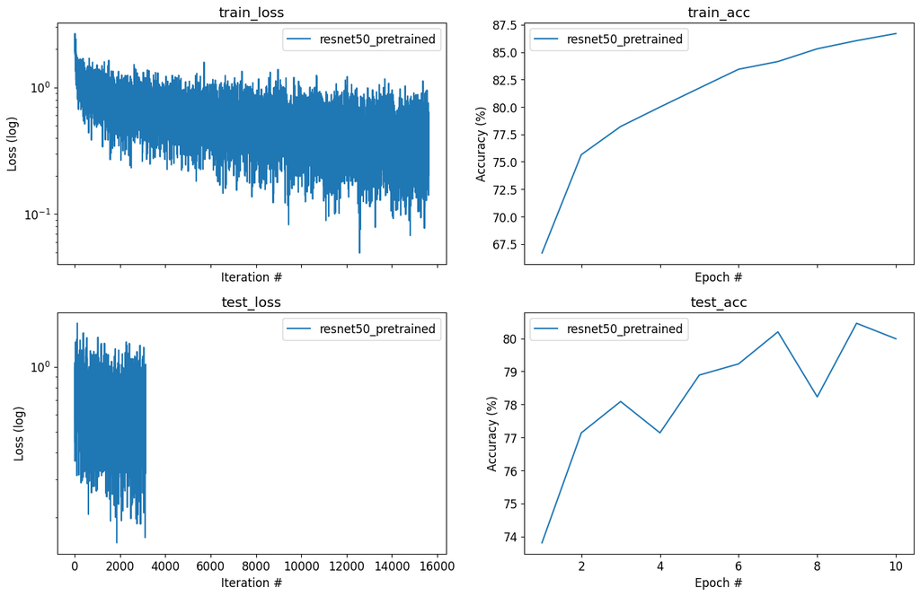

```python
plot_exp_results('exp6*') # plot your experiments results
```

**Answer in your Report:** What was the pretrained ResNet50 accuracy and loss? Is it overfit/underfit/well-fit the data? Has it got better accuracy than the non-pretrained ResNet? Summarize this section results in your report.

Read these blogs (and any other material you want):

1. https://jonathan-hui.medium.com/adversarial-attacks-b58318bb497b
2. https://medium.com/onfido-tech/adversarial-attacks-and-defences-for-convolutional-neural-networks-66915ece52e7

Write a summarization about adverserial attack (between one to two pages, in hebrew). Be sure that you answer the following question in your summarization (and add more info about this area, this is just a sanity check for you):

1. what it adverserial attack?
2. what are the types of adverserial attacks?
3. give at least one example of attack and possible defence?

## Project Summary

**Answer in your Report:** Write a short summerization of your attempts. What worked for you? which architecture and hyperparameters led to the best preformance?